# crasch Tutorial 2 - Input Files

Amy E. Arneson

Fall 2016

# Objectives

You should have already installed the software (`R`, RStudio, and the `crasch` package). If you have not, return to the Introduction and Tutorial 1.

- Receive sample data files to use as templates for your own study.
- Create an item information data file in the proper CSV format.
- Import the data files into an `R` session.
- Run the `craschR()` function on the imported data.

## Tutorial data

For this tutorial, we will use the ADP data. This was a construct developed for a study of teacher adoption of a cross-curricular writing “program” in a Missouri public high school in 2013.

Stage of adoption (abbreviated ADP) was 1 of 2 constructs measured for Amy’s 274A class project. Information about the construct, the items, the scoring, and the demographics collected can be found in the Tutorial2-documents folder on bCourses. All of the input file samples can also be found there.

*Create a folder called ADP on your desktop. Download all of the files from the `Tutorial2-documents` into this folder.*

# CSV files

You will need to create 3 input files to run your analysis. You may create an optional 4th file if you are collecting variables other than item responses. The files are as follows (names in parentheses are the corresponding arguments in the `craschR` function):

- construct information (`consInfo`),
- item information (`itemInfo`),
- scored responses (`scores`), and
- external variables (optional, `varsInfo`).

All of the files must be saved in the comma separated values (CSV) format. CSVs are editable in text editors (TextEdit, Notepad) or spreadsheet programs (Excel, Google Sheets, Numbers). In most of these applications, you will need to explicitly specify to “save as CSV” as it is not the default file type.

It is important that your files are structured and labeled (column headings) exactly as shown in this tutorial and in the sample data files. We recommend using these files as templates for your own data files. `crasch` will return an error if there are issues with the struction or labeling of your files.

## Construct information

Your construct information file will have:

- a header row,
- 1 row for each construct, and
- 3 columns for static construct information (ID, name, and abbreviation), and
- a column for each category of your construct.

*Open the `ADPcons.csv` file.*

Confirm that the information in the file matches the table below.

| cons.ID | long.name | short.name | cat1 | cat2 | cat3 | cat4 | cat5 |
| --- | --- | --- | --- | --- | --- | --- | --- |
| 22222 | Stage of Adoption | ADP | informed | persuaded | decided | implemented | confirmed |

*Open the `artifacts-adoption.pdf` file.* Confirm that the construct and category naming matches what is shown in that file.

- You will have as many `cat` columns as you have categories/levels of your construct. It is best to keep the names short. If you do not name your categories, you can simply call them “Level 1”, “Level 2”, etc. if you wish.
- The `cons.ID` can be any positive integer.
- **When you create your own files, it is imperative that the column headings exactly match what is provided in this file.** `R` is a case-senstive language, so the capitalization matters!
- If you have more than one construct, give each its own row in the your construct information file and each a unique `cons.ID`. (See Yukie or Amy if you are planning to measure more than one construct. It is not necessary for the class to do so.)

## Item information

*Open the `artifacts-adoption.pdf` and `ADPitem-INCOMPLETE.csv` files.*

- Note that the `cons.ID` exactly matches what was specified in the construct information file (in this case it is `ADPcons.csv`). If you are measuring more than one construct, you will put in the ID associated with whatever construct that item was scored on.
- The `item.type` and `fixed` will not play any part in your analysis. These exist for integration with the BASS web application. You can fill in `item.type` for your own records if you want. The `fixed` column should be `FALSE` for all items. These columns do need to exist in the file, however.
- Fill in `TRUE` (all caps) if the category exists in your outcome space/scoring guide. Fill in `FALSE` if it is not in your outcome space. *The first two rows of the file have been filled out for you. Compare the T/F designation to the outcome space tables below.*

| item.ID | item.name | cons.ID | item.type | fixed | cat1 | cat2 | cat3 | cat4 | cat5 |
| --- | --- | --- | --- | --- | --- | --- | --- | --- | --- |
| 1 | q8 | 22222 | MC | FALSE | TRUE | TRUE | TRUE | TRUE | TRUE |
| 2 | q12 | 22222 | FR | FALSE | TRUE | TRUE | TRUE | TRUE | FALSE |

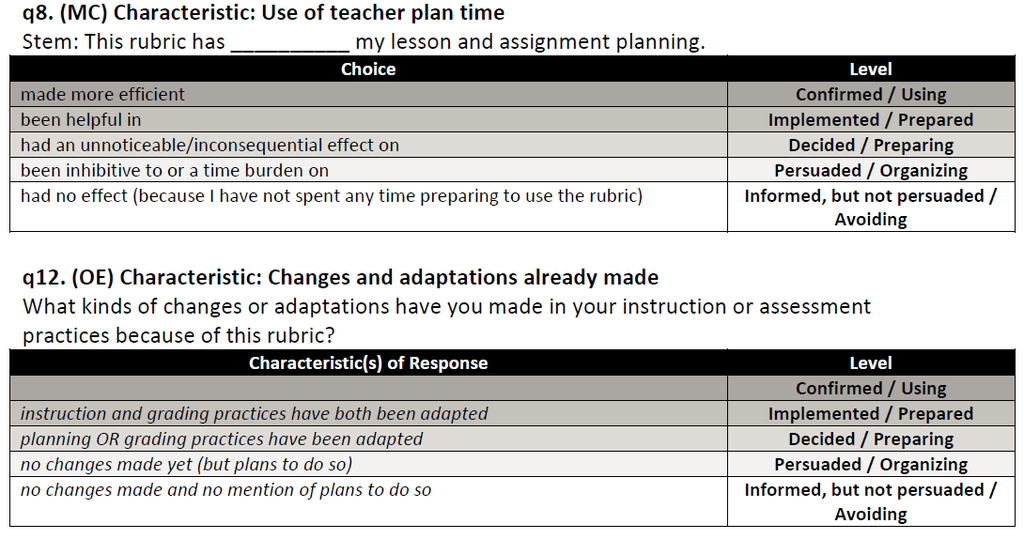

**Exercise:**

*Take 5 minutes to fill in the rest of the rows of the file using the outcome space tables provided in the `artifacts-adoption.pdf` file. When finished, compare what you built to the `ADPitem-KEY.csv` file.*

*Save your completed item information as `ADPitem.csv` in the same folder. Be sure to change the file type to `CSV` in the “Save As” dialog box.*

## Scored responses

*Open the `ADPwide.csv` file.* The scores for the first three respondents are reproduced below.

| . | q8 | q12 | q13 | q14 | q15 | q16 | q17 | q18 | q19 | q29 | q31 | q33 | q34 |
| --- | --- | --- | --- | --- | --- | --- | --- | --- | --- | --- | --- | --- | --- |
| 110 | 4 | 4 | 4 | 5 | 5 | 5 | 5 | 5 | 4 | 5 | 5 | 5 | 4 |
| 111 | 3 | 1 | 2 | 4 | 2 | 5 | 5 | 5 | 4 | NA | NA | NA | NA |
| 112 | 3 | 3 | 3 | 4 | 2 | 4 | 3 | 4 | 4 | NA | NA | NA | NA |

- Give unique respondent IDs (alphanumeric characters) in the first column. List your items - with the same names that appear in your item information file - in the top header row. Leave the top left corner cell *completely blank*. This configuration - with respondents as rows and items as columns - is known as *wide format*.
- Score each response into a category/level of your construct according to your outcome space. *If your outcome space changes during scoring, be sure to update your item information to reflect that!*
- Recall that construct categories/level are labeled starting at 1. There should not be any 0 scores or scores higher than your highest category/level.
- If you used a survey tools to collect responses, you may need to rescore. This can be done in Excel, Stata, R, or other data handling/spreadsheet program. If you need help with this, see one of us for assistance!
- Blanks or otherwise unscore-able responses must be coded as `NA` (all caps). This is the `R` code for “missing”, similar to the period in Stata. I recommend you do your recoding in Excel or in R so that the missing responses are coded correctly. (e.g. Stata’s missing code is “.”; that won’t fly in R.)

## Variable information

The variable information file is the most flexibly structured file. Note that variables included in this file are those that are external to the measurement of your target construct (background variables).

The values for the first three respondents in the `ADPvars.csv` file are reproduced below.

- `q1` is a code for the subject that the teacher taught in 2013. There are 10 possible subjects (mathematics, fine arts, physical education, etc.).
- `ELA/SS` is a dichotomized coding for q1. I decided that English-Language Arts (ELA) and Social Studies (SS) teachers would be most familiar with teaching and scoring writing assignments. So, I put them in one group and everyone else in “other.”
- `CORE` is another dichotomization of q1. The state-tested subjects (math and ELA) were labeled “core subjects” and all other subjects as “non-core”.
- `q2` is the number of years of teaching experience.
- `experience` is a dichotomization of q2. The two groups were teachers who have been teaching 5 years or less (“<= 5”) or 6 or more (“6+”)
- `q3` is the number of years the teacher has taught in the district.
- `tenure Y/N` is a dichotomization of q3. Any teacher who has taught more than 5 years in district automatically has tenure in the state of Missouri (“Y”). All others do not have tenure (“N”).
- `only job` is a dichotomization of q2 & q3. If the number of years of experience was equal to the number of years in district, then their current job has been their only teaching job.

| . | q1 | ELA/SS | CORE | q2 | experience | q3 | tenure Y/N | only job |
| --- | --- | --- | --- | --- | --- | --- | --- | --- |
| 110 | 2 | ELA/SS | core | 7 | 6+ | 7 | Y | Y |
| 111 | 9 | other | core | 30 | 6+ | 7 | Y | N |
| 112 | 6 | ELA/SS | core | 9 | 6+ | 6 | Y | N |

- Make sure the respondent IDs in the first column exactly match those in your scores file.
- The variable names and values can be *anything*. If you are dichotomizing, make sure that all group names match exactly. A typo or difference in case will be interpreted as a different group.

# Importing the files into `R` using `read.csv()`

To load your files into `R`, you will need to create an “object” and then refer to those objects in the `craschR()` arguments.

```
 - *Arguments* are the objects/values that you put inside the parentheses
   in an `R` function.
```

*Open RStudio.*

First, set your working directory to the folder where all of the tutorial documents exist. You can do this using the “Files” tab in the bottom right window in RStudio or with a line of code.

**All four CSV files that we discussed must be in your working directory.**

```r
setwd("C:/Users/Amy/Desktop/ADP") # for Windows
setwd("/Users/Amy/Desktop/ADP")   # for OSX

ADPcons = read.csv("ADPcons.csv", stringsAsFactors = FALSE)
# Check to make sure that it is formatted correctly
View(ADPcons) # or click on the object in the top right window of RStudio

ADPitem = read.csv("ADPitem.csv", stringsAsFactors = FALSE)
View(ADPitem)
# This won't work if you didn't save a copy of ADPitem.csv earlier
# If you did not, import ADPitem-KEY.csv instead

ADPscores = read.csv("ADPwide.csv", row.names = 1, stringsAsFactors = FALSE)
View(ADPscores)
# You must include the row.names argument or the first column will be interpreted
#   as a variable! You don't want that!

ADPvars = read.csv("ADPvars.csv", row.names = 1, stringsAsFactors = FALSE)
View(ADPvars)
```

Now, let’s run a quick analysis to make sure everything is formatted and was imported correctly. You’ll need to load the `crasch` library. This will only work if you installed the package in Tutorial 1.

Your analysis also needs to be an object. In the code below, I’ve named it `ADPanalysis`. Without doing this, you won’t be able to run any of the post-estimation functions that create some of the tables and graphs you will need.

```r
library(crasch)

?craschR # check the help file for the argument syntax
```

```
## starting httpd help server ...
```

```
##  done
```

```r
ADPanalysis = craschR(scores = ADPscores, itemInfo = ADPitem, consInfo = ADPcons,
              varsInfo = ADPvars)
```

```
## Assuming partial credit model
```

Let’s run a post-estimation function, `item.scores()`. This function will produce tables and a graphic showing score distributions by item.

```r
?item.scores # check the help file for the arguments
item.scores(ADPanalysis) # runs the function with all defaults
```

```
## No output was written to file. If you wish to write to file, use writeout=TRUE.
```

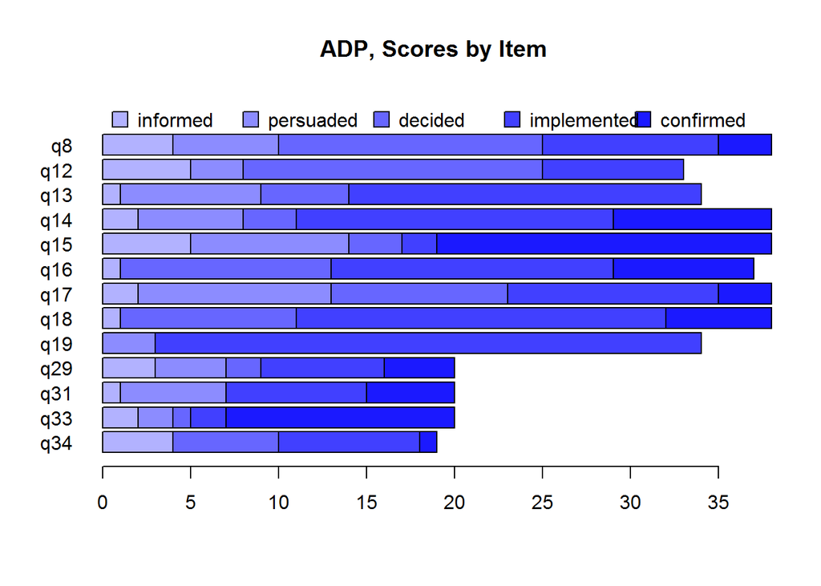

```
## $ADP
## $ADP$counts
##     informed persuaded decided implemented confirmed
## q8         4         6      15          10         3
## q12        5         3      17           8
## q13        1         8       5          20
## q14        2         6       3          18         9
## q15        5         9       3           2        19
## q16        1         0      12          16         8
## q17        2        11      10          12         3
## q18        1                10          21         6
## q19        0         3                  31
## q29        3         4       2           7         4
## q31        1         6                   8         5
## q33        2         2       1           2        13
## q34        4                 6           8         1
##
## $ADP$proportions
##       informed  persuaded    decided implemented  confirmed
## q8  0.10526316 0.15789474 0.39473684  0.26315789 0.07894737
## q12 0.15151515 0.09090909 0.51515152  0.24242424
## q13 0.02941176 0.23529412 0.14705882  0.58823529
## q14 0.05263158 0.15789474 0.07894737  0.47368421 0.23684211
## q15 0.13157895 0.23684211 0.07894737  0.05263158 0.50000000
## q16 0.02702703 0.00000000 0.32432432  0.43243243 0.21621622
## q17 0.05263158 0.28947368 0.26315789  0.31578947 0.07894737
## q18 0.02631579            0.26315789  0.55263158 0.15789474
## q19 0.00000000 0.08823529             0.91176471
## q29 0.15000000 0.20000000 0.10000000  0.35000000 0.20000000
## q31 0.05000000 0.30000000             0.40000000 0.25000000
## q33 0.10000000 0.10000000 0.05000000  0.10000000 0.65000000
## q34 0.21052632            0.31578947  0.42105263 0.05263158
```

```r
# to write the tables and graphic to a file
item.scores(ADPanalysis, writeout = TRUE)
```

```
## $ADP
## $ADP$counts
##     informed persuaded decided implemented confirmed
## q8         4         6      15          10         3
## q12        5         3      17           8
## q13        1         8       5          20
## q14        2         6       3          18         9
## q15        5         9       3           2        19
## q16        1         0      12          16         8
## q17        2        11      10          12         3
## q18        1                10          21         6
## q19        0         3                  31
## q29        3         4       2           7         4
## q31        1         6                   8         5
## q33        2         2       1           2        13
## q34        4                 6           8         1
##
## $ADP$proportions
##       informed  persuaded    decided implemented  confirmed
## q8  0.10526316 0.15789474 0.39473684  0.26315789 0.07894737
## q12 0.15151515 0.09090909 0.51515152  0.24242424
## q13 0.02941176 0.23529412 0.14705882  0.58823529
## q14 0.05263158 0.15789474 0.07894737  0.47368421 0.23684211
## q15 0.13157895 0.23684211 0.07894737  0.05263158 0.50000000
## q16 0.02702703 0.00000000 0.32432432  0.43243243 0.21621622
## q17 0.05263158 0.28947368 0.26315789  0.31578947 0.07894737
## q18 0.02631579            0.26315789  0.55263158 0.15789474
## q19 0.00000000 0.08823529             0.91176471
## q29 0.15000000 0.20000000 0.10000000  0.35000000 0.20000000
## q31 0.05000000 0.30000000             0.40000000 0.25000000
## q33 0.10000000 0.10000000 0.05000000  0.10000000 0.65000000
## q34 0.21052632            0.31578947  0.42105263 0.05263158
```

```
## No output was written to file. If you wish to write to file, use writeout=TRUE.
```

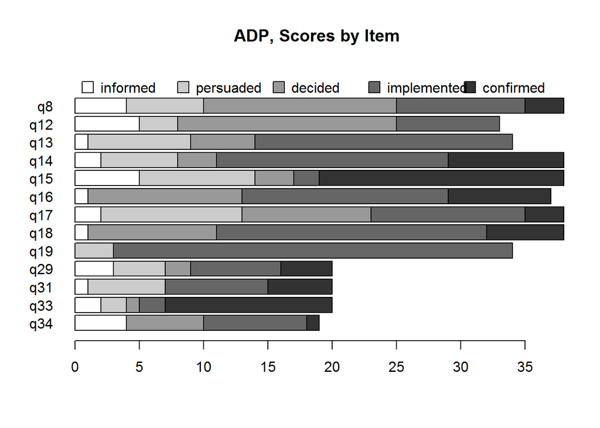

```
## $ADP
## $ADP$counts
##     informed persuaded decided implemented confirmed
## q8         4         6      15          10         3
## q12        5         3      17           8
## q13        1         8       5          20
## q14        2         6       3          18         9
## q15        5         9       3           2        19
## q16        1         0      12          16         8
## q17        2        11      10          12         3
## q18        1                10          21         6
## q19        0         3                  31
## q29        3         4       2           7         4
## q31        1         6                   8         5
## q33        2         2       1           2        13
## q34        4                 6           8         1
##
## $ADP$proportions
##       informed  persuaded    decided implemented  confirmed
## q8  0.10526316 0.15789474 0.39473684  0.26315789 0.07894737
## q12 0.15151515 0.09090909 0.51515152  0.24242424
## q13 0.02941176 0.23529412 0.14705882  0.58823529
## q14 0.05263158 0.15789474 0.07894737  0.47368421 0.23684211
## q15 0.13157895 0.23684211 0.07894737  0.05263158 0.50000000
## q16 0.02702703 0.00000000 0.32432432  0.43243243 0.21621622
## q17 0.05263158 0.28947368 0.26315789  0.31578947 0.07894737
## q18 0.02631579            0.26315789  0.55263158 0.15789474
## q19 0.00000000 0.08823529             0.91176471
## q29 0.15000000 0.20000000 0.10000000  0.35000000 0.20000000
## q31 0.05000000 0.30000000             0.40000000 0.25000000
## q33 0.10000000 0.10000000 0.05000000  0.10000000 0.65000000
## q34 0.21052632            0.31578947  0.42105263 0.05263158
```

```r
# to change the colors in the graphic to grayscale
item.scores(ADPanalysis, palette = "grey")
```

```
## No output was written to file. If you wish to write to file, use writeout=TRUE.
```

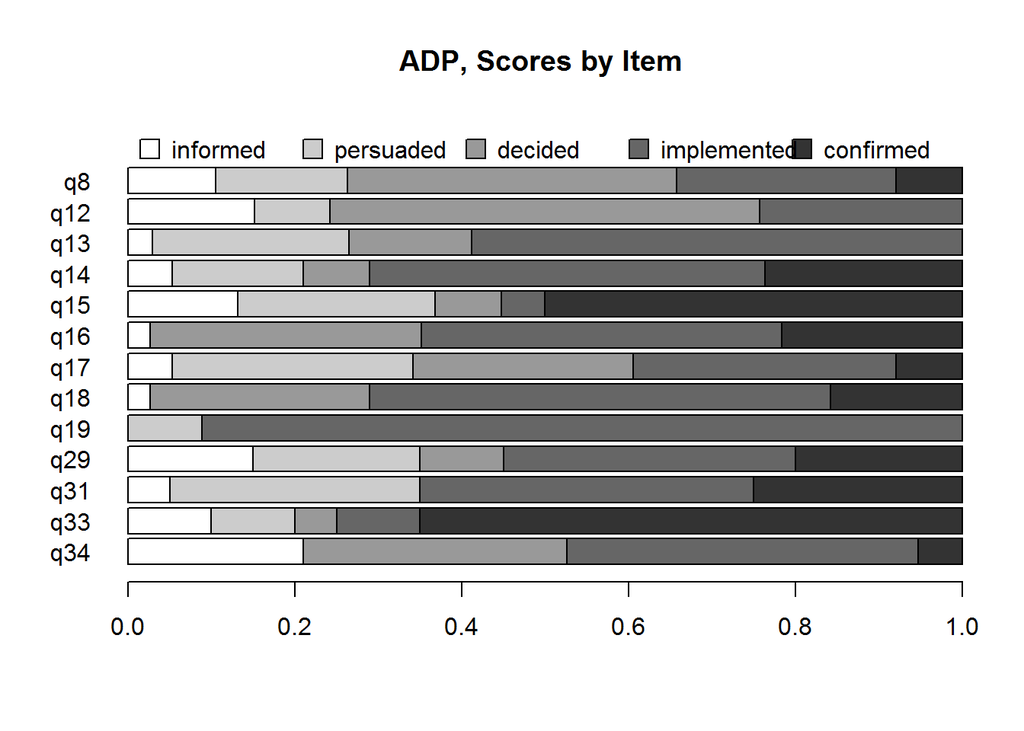

```
## $ADP
## $ADP$counts
##       informed  persuaded    decided implemented  confirmed
## q8  0.10526316 0.15789474 0.39473684  0.26315789 0.07894737
## q12 0.15151515 0.09090909 0.51515152  0.24242424
## q13 0.02941176 0.23529412 0.14705882  0.58823529
## q14 0.05263158 0.15789474 0.07894737  0.47368421 0.23684211
## q15 0.13157895 0.23684211 0.07894737  0.05263158 0.50000000
## q16 0.02702703 0.00000000 0.32432432  0.43243243 0.21621622
## q17 0.05263158 0.28947368 0.26315789  0.31578947 0.07894737
## q18 0.02631579            0.26315789  0.55263158 0.15789474
## q19 0.00000000 0.08823529             0.91176471
## q29 0.15000000 0.20000000 0.10000000  0.35000000 0.20000000
## q31 0.05000000 0.30000000             0.40000000 0.25000000
## q33 0.10000000 0.10000000 0.05000000  0.10000000 0.65000000
## q34 0.21052632            0.31578947  0.42105263 0.05263158
##
## $ADP$proportions
##       informed  persuaded    decided implemented  confirmed
## q8  0.10526316 0.15789474 0.39473684  0.26315789 0.07894737
## q12 0.15151515 0.09090909 0.51515152  0.24242424
## q13 0.02941176 0.23529412 0.14705882  0.58823529
## q14 0.05263158 0.15789474 0.07894737  0.47368421 0.23684211
## q15 0.13157895 0.23684211 0.07894737  0.05263158 0.50000000
## q16 0.02702703 0.00000000 0.32432432  0.43243243 0.21621622
## q17 0.05263158 0.28947368 0.26315789  0.31578947 0.07894737
## q18 0.02631579            0.26315789  0.55263158 0.15789474
## q19 0.00000000 0.08823529             0.91176471
## q29 0.15000000 0.20000000 0.10000000  0.35000000 0.20000000
## q31 0.05000000 0.30000000             0.40000000 0.25000000
## q33 0.10000000 0.10000000 0.05000000  0.10000000 0.65000000
## q34 0.21052632            0.31578947  0.42105263 0.05263158
```

```r
# to plot proportions instead of frequencies
item.scores(ADPanalysis, freqs = FALSE, palette = "grey")
```

# Closing

- If you are getting errors or unexpected results, please see Amy or Yukie during office hours.
- In the next tutorial, we will cover all `crasch` functions.
  - `item.scores()` produces tables and graphs for the score distribution by item
  - `pers.hist()` produces a histogram of the estimated person locations with a normal curve overlaid
  - `KIDMAP()` produces a KIDMAP graphic for a given respondent
  - `item.analysis()` produces by item and by step tables with estimates, fit statistics, and classical statistics
  - `infit.MNSQ()` produces a graphic of item fit statistics by item
  - `CPC.graph()` produces graphics of the cumulative probability curves by item
  - `ICC.graph()` produces graphics of the item (or category) characteristic curves by item
  - `info.graph()` produces graphics of the test and item information
  - `wm()` a wrapper for the `wrightMap()` function
  - `split.halves()` calculates the split halves reliability coefficient
  - `mean.traj()` produces a graphic showing the mean location trajectories of respondents by item
  - `Sp.rho()` calculates Spearman’s rho
- There are some base `R` functions that we will also cover.
  - `cor(method = "pearson")` for calculating correlations with continuous external variables